# 2024 Little Susitna - Chinook

Nick DeCovich

This is a preliminary look at ASL estimates for Little Susitna Chinook. The weir was flooded and not fish tight June 16 - 21, and the video weir was not operational due to water clarity for a majority of the month of June. Fish were sampled by blind scooping the fish cage during this time. Therefore, these estimates are not relatable to actual passage.

## Chinook ASL

| strata | asl_dates | asl_pct | escapement_dates | escapement_pct |
| --- | --- | --- | --- | --- |
| 1 | May 27 to Jun 27 | 0.45 | May 13 to Jun 27 | 0.23 |
| 2 | Jun 28 to Jul 04 | 0.34 | Jun 28 to Jul 04 | 0.29 |
| 3 | Jul 05 to Jul 08 | 0.08 | Jul 05 to Jul 08 | 0.23 |
| 4 | Jul 09 to Jul 16 | 0.13 | Jul 09 to Aug 09 | 0.25 |

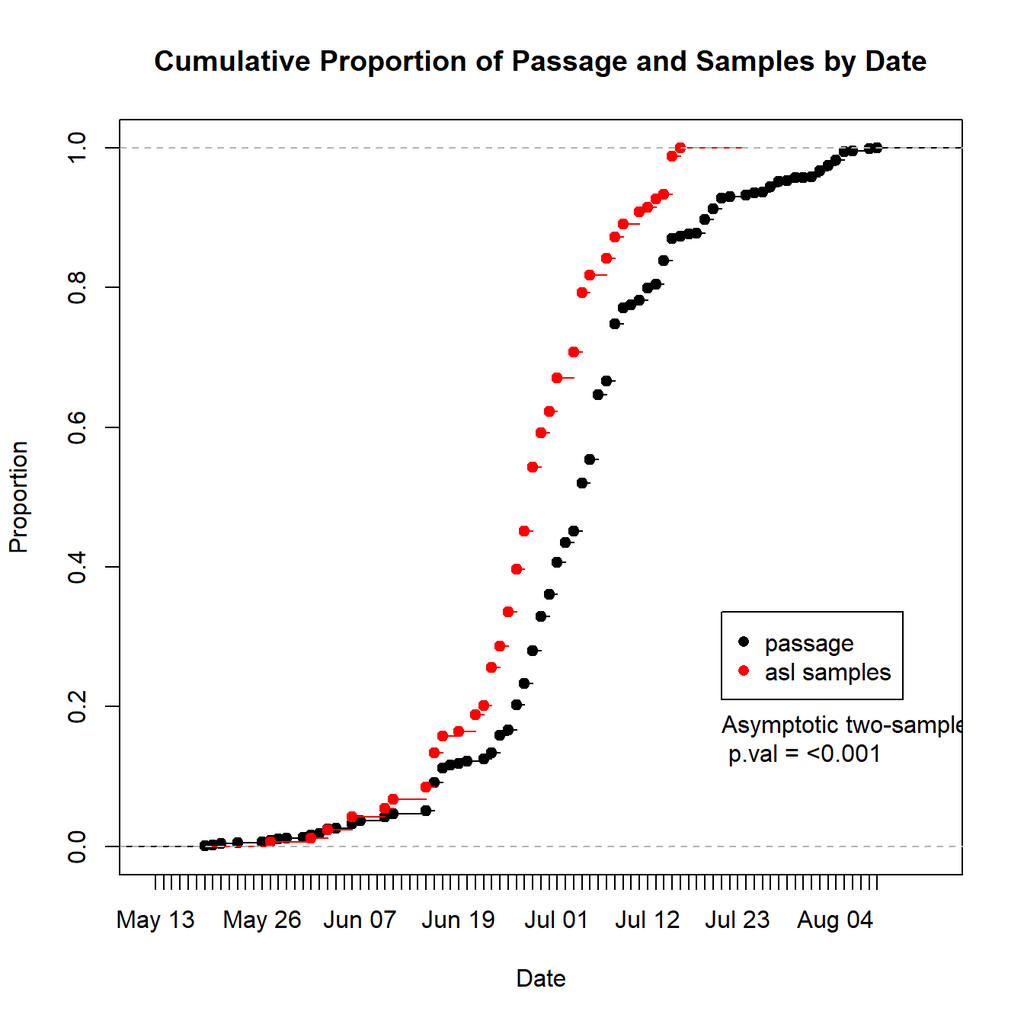

```
##
##  Exact two-sample Kolmogorov-Smirnov test
##
## data:  weir$passage and weir$samples
## D = 0.41573, p-value = 6.569e-08
## alternative hypothesis: two-sided
```

The sampling was NOT proportional to the run.

### Chinook sex composition

Likelihood ratio test indicates sex composition *did not* differ between time strata.

```
##
##         F   M Sum
##   1    11  63  74
##   2     6  50  56
##   3     1  12  13
##   4     2  19  21
##   Sum  20 144 164
```

```
##
##  Log likelihood ratio (G-test) test of independence without correction
##
## data:  t.sex
## G = 1.0121, X-squared df = 3, p-value = 0.7983
```

Here is the Chinook sex-length table. We used an un-stratified estimate and met the precision objective.

| sex_lab | Sample size | Proportion (SE) | 95% CI(Proportion) | Weir Passage(SE) | Mean Length (SE) | Range(Length) |
| --- | --- | --- | --- | --- | --- | --- |
| Females | 20 | 0.122 (0.023) | 0.080 - 0.181 | 124 (24) | 718.1 (24.8) | (500-900) |
| Males | 144 | 0.878 (0.023) | 0.819 - 0.920 | 890 (24) | 524.0 (8.7) | (330-820) |
| Both Sexes | 164 | 1.000 (0) |  | 1,014 (0) | 547.7 (9.6) | (330-900) |

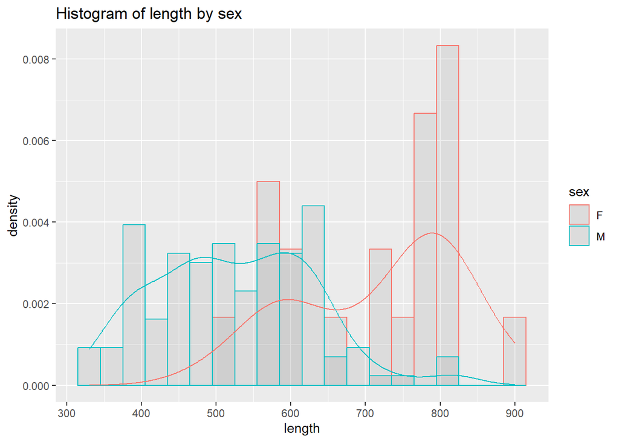

### Chinook age composition

Likelihood ratio tests indicate age composition *does not* differ between time strata.

```
## [1] OBSERVED COUNTS
```

```
##
##       1.1 1.2 1.3 1.4 Sum
##   1    37  20   8   0  65
##   2    25  17   5   1  48
##   3     5   4   2   0  11
##   4    15   3   1   0  19
##   Sum  82  44  16   1 143
```

```
## [1] EXPECTED COUNTS
```

```
##     1.1 1.2 1.3 1.4 Sum
## 1    37  20   7   0  64
## 2    28  15   5   0  48
## 3     6   3   1   0  10
## 4    11   6   2   0  19
## Sum  82  44  15   0 141
```

```
##
##  Log likelihood ratio (G-test) test of independence without correction
##
## data:  t.age
## G = 7.4583, X-squared df = 9, p-value = 0.5895
```

Here is the Chinook age-length table. We used an un-stratified estimate and met the precision objective. As previously mentioned, weir passage by age, sex and length does not represent weir passage because the weir was not fish tight during the bulk of the run.

| age_lab | Sample size | Proportion (SE) | 95% CI(Proportion) | Weir(SE) | Mean Length (SE) | Range(Length) |
| --- | --- | --- | --- | --- | --- | --- |
| 1.1 | 82 | 0.573 (0.038) | 0.491 - 0.652 | 581 (39) | 472.4 (8.3) | (330-630) |
| 1.2 | 44 | 0.308 (0.036) | 0.238 - 0.388 | 312 (36) | 621.6 (5.6) | (545-710) |
| 1.3 | 16 | 0.112 (0.025) | 0.070 - 0.174 | 113 (25) | 785.5 (9.1) | (710-820) |
| 1.4 | 1 | 0.007 (0.006) | 0.001 - 0.039 | 7 (7) | 900.0 (NA) | (900-900) |
| All ages | 143 | 1.000 (0) |  | 1,014 (0) | 556.3 (10.5) | (330-900) |

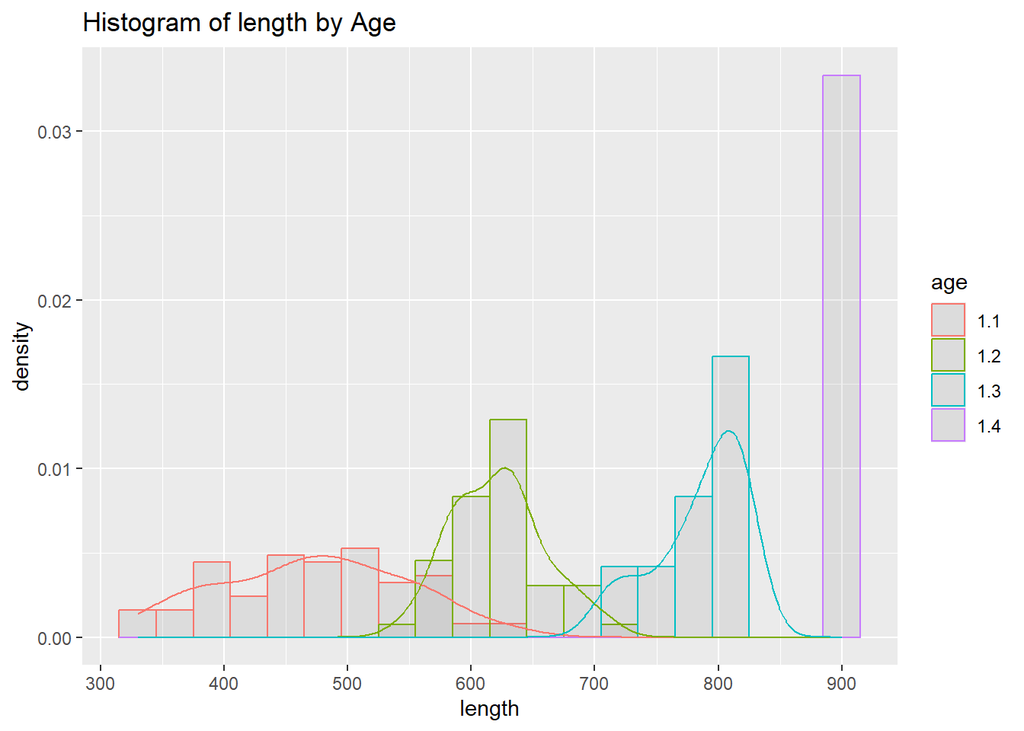

### Chinook age-sex composition

Here is the Chinook age-sex-length table. As previously mentioned, weir passage by age, sex and length does not represent weir passage because the weir was not fish tight during the bulk of the run.

| sex_lab | stat_lab | 1.1 | 1.2 | 1.3 | 1.4 | All ages |
| --- | --- | --- | --- | --- | --- | --- |
| Females | Sample size | 1 | 6 | 11 | 1 | 19 |
| Females | Proportion (SE) | 0.007 (0.006) | 0.042 (0.016) | 0.077 (0.021) | 0.007 (0.006) | 0.133 (0.026) |
| Females | 95% CI(Proportion) | 0.001 - 0.039 | 0.019 - 0.089 | 0.043 - 0.132 | 0.001 - 0.039 | 0.087 - 0.198 |
| Females | Weir(SE) | 7 (7) | 43 (16) | 78 (21) | 7 (7) | 135 (27) |
| Females | Mean Length (SE) | 610.0 (NA) | 615.8 (23.0) | 787.1 (9.7) | 900.0 (NA) | 729.6 (23.2) |
| Females | Range(Length) | (610-610) | (570-710) | (710-820) | (900-900) | (570-900) |
| Males | Sample size | 81 | 38 | 5 | NA | 124 |
| Males | Proportion (SE) | 0.566 (0.039) | 0.266 (0.034) | 0.035 (0.014) | NA | 0.867 (0.026) |
| Males | 95% CI(Proportion) | 0.485 - 0.645 | 0.200 - 0.344 | 0.015 - 0.079 | NA | 0.802 - 0.913 |
| Males | Weir(SE) | 574 (39) | 269 (35) | 35 (14) | NA | 879 (27) |
| Males | Mean Length (SE) | 470.7 (8.2) | 622.5 (5.6) | 782.0 (21.5) | NA | 529.8 (9.6) |
| Males | Range(Length) | (330-630) | (545-700) | (720-820) | NA | (330-820) |
| Both Sexes | Sample size | 82 | 44 | 16 | 1 | 143 |
| Both Sexes | Proportion (SE) | 0.573 (0.038) | 0.308 (0.036) | 0.112 (0.025) | 0.007 (0.006) | 1.000 (0) |
| Both Sexes | 95% CI(Proportion) | 0.491 - 0.652 | 0.238 - 0.388 | 0.070 - 0.174 | 0.001 - 0.039 |  |
| Both Sexes | Weir(SE) | 581 (39) | 312 (36) | 113 (25) | 7 (7) | 1,014 (0) |
| Both Sexes | Mean Length (SE) | 472.4 (8.3) | 621.6 (5.6) | 785.5 (9.1) | 900.0 (NA) | 556.3 (10.5) |
| Both Sexes | Range(Length) | (330-630) | (545-710) | (710-820) | (900-900) | (330-900) |

# ASL TABLES

## Chinook Sex Comp

|  | sex_lab | Sample size | Proportion (SE) | 95% CI(Proportion) | Weir Passage(SE) | Mean Length (SE) | Range(Length) |
| --- | --- | --- | --- | --- | --- | --- | --- |
| 1 | Females | 20 | 0.122 (0.023) | 0.080 - 0.181 | 124 (24) | 718.1 (24.8) | (500-900) |
| 2 | Males | 144 | 0.878 (0.023) | 0.819 - 0.920 | 890 (24) | 524.0 (8.7) | (330-820) |
| 3 | Both Sexes | 164 | 1.000 (0) |  | 1,014 (0) | 547.7 (9.6) | (330-900) |

## Chinook Age Comp

|  | age_lab | Sample size | Proportion (SE) | 95% CI(Proportion) | Weir(SE) | Mean Length (SE) | Range(Length) |
| --- | --- | --- | --- | --- | --- | --- | --- |
| 1 | 1.1 | 82 | 0.573 (0.038) | 0.491 - 0.652 | 581 (39) | 472.4 (8.3) | (330-630) |
| 2 | 1.2 | 44 | 0.308 (0.036) | 0.238 - 0.388 | 312 (36) | 621.6 (5.6) | (545-710) |
| 3 | 1.3 | 16 | 0.112 (0.025) | 0.070 - 0.174 | 113 (25) | 785.5 (9.1) | (710-820) |
| 4 | 1.4 | 1 | 0.007 (0.006) | 0.001 - 0.039 | 7 (7) | 900.0 (NA) | (900-900) |
| 5 | All ages | 143 | 1.000 (0) |  | 1,014 (0) | 556.3 (10.5) | (330-900) |

## Chinook SexAge Comp

|  | sex_lab | stat_lab | 1.1 | 1.2 | 1.3 | 1.4 | All ages |
| --- | --- | --- | --- | --- | --- | --- | --- |
| 1 | Females | Sample size | 1 | 6 | 11 | 1 | 19 |
| 2 | Females | Proportion (SE) | 0.007 (0.006) | 0.042 (0.016) | 0.077 (0.021) | 0.007 (0.006) | 0.133 (0.026) |
| 3 | Females | 95% CI(Proportion) | 0.001 - 0.039 | 0.019 - 0.089 | 0.043 - 0.132 | 0.001 - 0.039 | 0.087 - 0.198 |
| 4 | Females | Weir(SE) | 7 (7) | 43 (16) | 78 (21) | 7 (7) | 135 (27) |
| 5 | Females | Mean Length (SE) | 610.0 (NA) | 615.8 (23.0) | 787.1 (9.7) | 900.0 (NA) | 729.6 (23.2) |
| 6 | Females | Range(Length) | (610-610) | (570-710) | (710-820) | (900-900) | (570-900) |
| 7 | Males | Sample size | 81 | 38 | 5 |  | 124 |
| 8 | Males | Proportion (SE) | 0.566 (0.039) | 0.266 (0.034) | 0.035 (0.014) |  | 0.867 (0.026) |
| 9 | Males | 95% CI(Proportion) | 0.485 - 0.645 | 0.200 - 0.344 | 0.015 - 0.079 |  | 0.802 - 0.913 |
| 10 | Males | Weir(SE) | 574 (39) | 269 (35) | 35 (14) |  | 879 (27) |

[output cut: 8 more lines]